# Final Project

Linear Models

Author

Brian Witarsa

Published

May 8, 2025

# Final Project | Step One

## Exploratory Data Analysis

```r
library(dplyr)
library(ggplot2)
library(lmtest)
library(rms)
library(MASS)
```

```r
cancer_df <- read.csv('DS64510_Project_Data.csv')

formula1 <- as.formula(TARGET_deathRate ~ povertyPercent + PctPublicCoverage + PctEmpPrivCoverage + PctPrivateCoverage + studyPerCap + medIncome + MedianAge)
cor_variables <- cancer_df |>
  dplyr::select(TARGET_deathRate, povertyPercent, PctPublicCoverage,
          PctUnemployed16_Over, PctPrivateCoverage, incidenceRate, medIncome, MedianAge)

cor_matrix <- cor(cor_variables, use="complete.obs")
print(cor_matrix)
```

```
                     TARGET_deathRate povertyPercent PctPublicCoverage
TARGET_deathRate          1.000000000    0.429388980        0.40457166
povertyPercent            0.429388980    1.000000000        0.65116206
PctPublicCoverage         0.404571656    0.651162060        1.00000000
PctUnemployed16_Over      0.378412442    0.655148122        0.52982130
PctPrivateCoverage       -0.386065507   -0.822534292       -0.72001152
incidenceRate             0.449431698    0.009046252        0.04610861
medIncome                -0.428614927   -0.788965239       -0.75482175
MedianAge                 0.004375077   -0.029279996        0.04906021
                     PctUnemployed16_Over PctPrivateCoverage incidenceRate
TARGET_deathRate               0.37841244       -0.386065507   0.449431698
povertyPercent                 0.65514812       -0.822534292   0.009046252
PctPublicCoverage              0.52982130       -0.720011521   0.046108610
PctUnemployed16_Over           1.00000000       -0.634317281   0.099979455
PctPrivateCoverage            -0.63431728        1.000000000   0.105174269
incidenceRate                  0.09997946        0.105174269   1.000000000
medIncome                     -0.45310766        0.724174768  -0.001036186
MedianAge                      0.01859044        0.004665111   0.018089172
                        medIncome    MedianAge
TARGET_deathRate     -0.428614927  0.004375077
povertyPercent       -0.788965239 -0.029279996
PctPublicCoverage    -0.754821751  0.049060211
PctUnemployed16_Over -0.453107661  0.018590443
PctPrivateCoverage    0.724174768  0.004665111
incidenceRate        -0.001036186  0.018089172
medIncome             1.000000000 -0.013287743
MedianAge            -0.013287743  1.000000000
```

## Multicolinearity

There are several variables that are highly correlated:

1. Poverty Percent <–> Private Coverage Percentage
2. Poverty Percent <–> Median Income
3. Public Coverage Percentage <–> Median Income
4. Public Coverage Percentage <–> Private Coverage Percentage

Highly correlated values cause multicolinearity in the model, which produce inaccurate estimates.

Poverty Percent

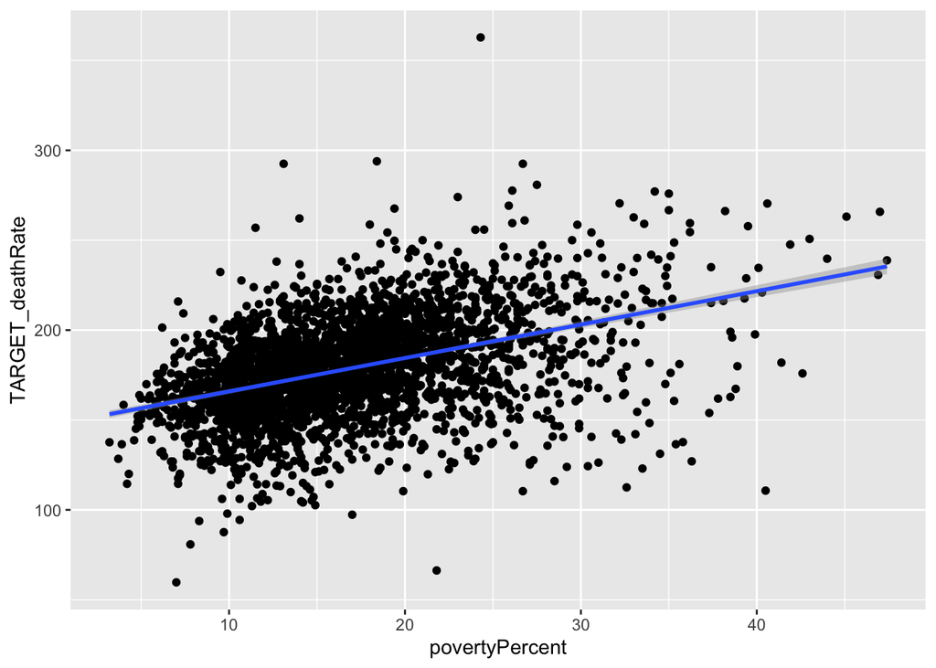

```r
ggplot(cancer_df, aes(x = povertyPercent, y = TARGET_deathRate)) +
  geom_point() + geom_smooth(method = "lm")
```

Poverty Percentage has a positive correlation with TARGET_deathRate. The higher the poverty rate, the higher the deathRate.

Public Coverage Percentage

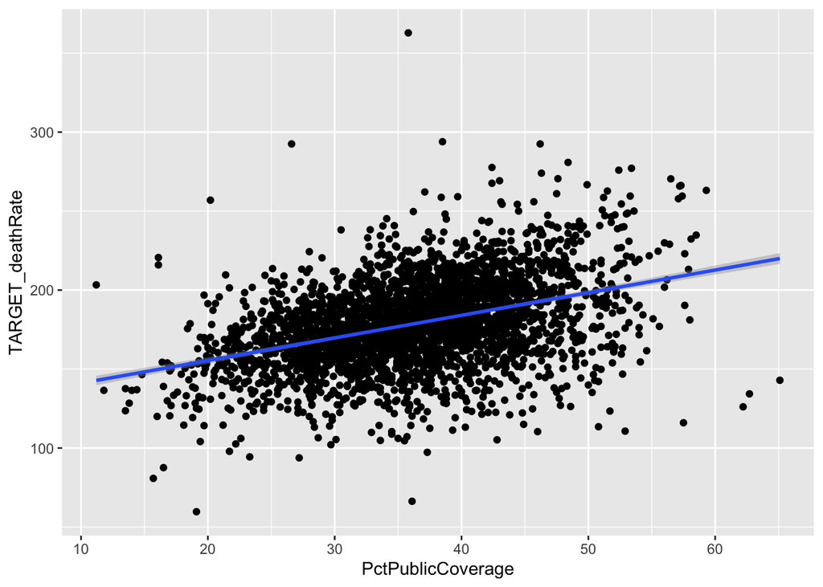

```r
ggplot(cancer_df, aes(x = PctPublicCoverage, y = TARGET_deathRate)) +
  geom_point() + geom_smooth(method = "lm")
```

Median Income

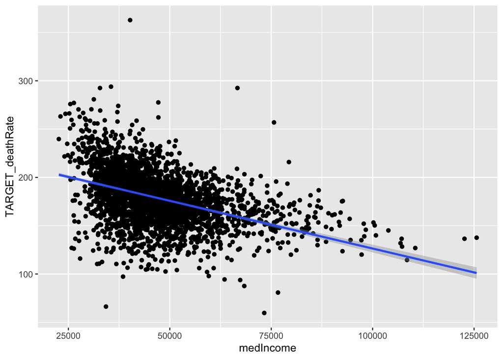

```r
ggplot(cancer_df, aes(x = medIncome, y = TARGET_deathRate)) +
  geom_point() + geom_smooth(method = "lm")
```

Median Income has a negative correlation with TARGET_deathRate. The higher the Median Income, the lower the deathRate.

Incidence Rate

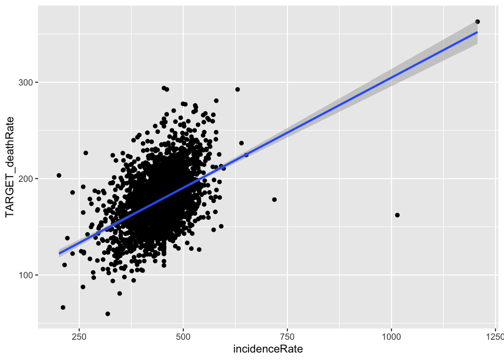

```r
ggplot(cancer_df, aes(x = incidenceRate, y = TARGET_deathRate)) +
  geom_point() + geom_smooth(method = "lm")
```

## Multivariate Scatter Plot

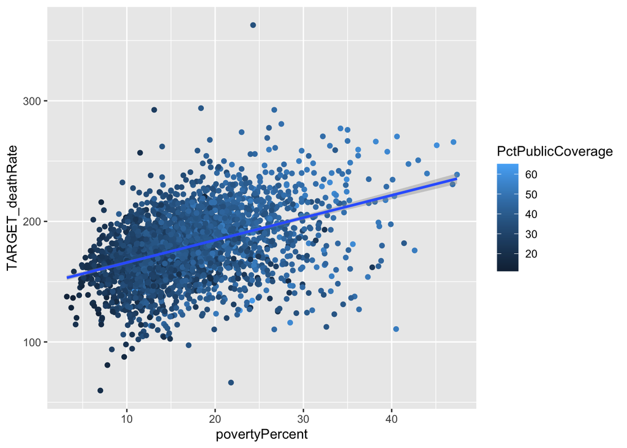

```r
ggplot(cancer_df, aes(x = povertyPercent, y = TARGET_deathRate, color = PctPublicCoverage)) +
  geom_point() +
  geom_smooth(method = "lm")
```

Poverty Percentage has a positive correlation with TARGET_deathRate. When Public Coverage Percentage increases, both the deathRate and Poverty Percentage increases.

# Step Two

```r
model <- lm(formula1, data=cancer_df)
summary(model)
```

```
Call:
lm(formula = formula1, data = cancer_df)

Residuals:
     Min       1Q   Median       3Q      Max
-120.161  -13.330   -0.116   13.425  173.061

Coefficients:
                     Estimate Std. Error t value Pr(>|t|)
(Intercept)         1.433e+02  9.965e+00  14.382  < 2e-16 ***
povertyPercent      6.348e-01  1.401e-01   4.532 6.06e-06 ***
PctPublicCoverage   1.047e+00  9.729e-02  10.767  < 2e-16 ***
PctEmpPrivCoverage  1.344e+00  9.614e-02  13.975  < 2e-16 ***
PctPrivateCoverage -6.466e-01  9.417e-02  -6.866 7.96e-12 ***
studyPerCap        -5.462e-04  8.215e-04  -0.665    0.506
medIncome          -5.789e-04  7.083e-05  -8.173 4.38e-16 ***
MedianAge           5.259e-03  9.585e-03   0.549    0.583
---
Signif. codes:  0 '***' 0.001 '**' 0.01 '*' 0.05 '.' 0.1 ' ' 1

Residual standard error: 23.83 on 3039 degrees of freedom
Multiple R-squared:  0.2641,    Adjusted R-squared:  0.2624
F-statistic: 155.8 on 7 and 3039 DF,  p-value: < 2.2e-16
```

# Step Three

## Model Selection

```r
ols.mod1 <- ols(formula1, data=cancer_df)
fastbw(ols.mod1, rule="p", sls=0.05)
```

```
 Deleted     Chi-Sq d.f. P      Residual d.f. P      AIC   R2
 MedianAge   0.30   1    0.5832 0.30     1    0.5832 -1.70 0.264
 studyPerCap 0.46   1    0.4975 0.76     2    0.6834 -3.24 0.264

Approximate Estimates after Deleting Factors

                         Coef      S.E. Wald Z         P
Intercept           1.438e+02 9.9515368 14.448 0.000e+00
povertyPercent      6.300e-01 0.1398885  4.504 6.676e-06
PctPublicCoverage   1.048e+00 0.0971216 10.793 0.000e+00
PctEmpPrivCoverage  1.338e+00 0.0958992 13.949 0.000e+00
PctPrivateCoverage -6.475e-01 0.0940836 -6.883 5.879e-12
medIncome          -5.777e-04 0.0000708 -8.160 3.331e-16

Factors in Final Model

[1] povertyPercent     PctPublicCoverage  PctEmpPrivCoverage PctPrivateCoverage
[5] medIncome
```

1. MedianAge and studyPerCap both did not have a significant p value in the previous model. Actually they both have the highest p values, and the fastbw method reflects that.

```r
aic_result <- stepAIC(model)
```

```
Start:  AIC=19332.87
TARGET_deathRate ~ povertyPercent + PctPublicCoverage + PctEmpPrivCoverage +
    PctPrivateCoverage + studyPerCap + medIncome + MedianAge

                     Df Sum of Sq     RSS   AIC
- MedianAge           1       171 1726571 19331
- studyPerCap         1       251 1726651 19331
<none>                            1726400 19333
- povertyPercent      1     11669 1738069 19351
- PctPrivateCoverage  1     26782 1753182 19378
- medIncome           1     37942 1764342 19397
- PctPublicCoverage   1     65853 1792254 19445
- PctEmpPrivCoverage  1    110950 1837350 19521

Step:  AIC=19331.17
TARGET_deathRate ~ povertyPercent + PctPublicCoverage + PctEmpPrivCoverage +
    PctPrivateCoverage + studyPerCap + medIncome

                     Df Sum of Sq     RSS   AIC
- studyPerCap         1       262 1726833 19330
<none>                            1726571 19331
- povertyPercent      1     11559 1738130 19350
- PctPrivateCoverage  1     26694 1753265 19376
- medIncome           1     37972 1764543 19396
- PctPublicCoverage   1     66369 1792940 19444
- PctEmpPrivCoverage  1    110782 1837353 19519

Step:  AIC=19329.63
TARGET_deathRate ~ povertyPercent + PctPublicCoverage + PctEmpPrivCoverage +
    PctPrivateCoverage + medIncome

                     Df Sum of Sq     RSS   AIC
<none>                            1726833 19330
- povertyPercent      1     11523 1738356 19348
- PctPrivateCoverage  1     26910 1753742 19375
- medIncome           1     37826 1764658 19394
- PctPublicCoverage   1     66181 1793014 19442
- PctEmpPrivCoverage  1    110542 1837374 19517
```

1. MedianAge and studyPerCap both did not have a significant p value in the previous model and the stepAIC method reflects that. Those were the only two predictors removed from the model.

### I am choosing to continue with the stepAIC model.

```r
summary(aic_result)
```

```
Call:
lm(formula = TARGET_deathRate ~ povertyPercent + PctPublicCoverage +
    PctEmpPrivCoverage + PctPrivateCoverage + medIncome, data = cancer_df)

Residuals:
     Min       1Q   Median       3Q      Max
-120.183  -13.289   -0.142   13.401  173.157

Coefficients:
                     Estimate Std. Error t value Pr(>|t|)
(Intercept)         1.438e+02  9.950e+00  14.451  < 2e-16 ***
povertyPercent      6.300e-01  1.399e-01   4.505 6.90e-06 ***
PctPublicCoverage   1.048e+00  9.710e-02  10.796  < 2e-16 ***
PctEmpPrivCoverage  1.338e+00  9.588e-02  13.952  < 2e-16 ***
PctPrivateCoverage -6.475e-01  9.406e-02  -6.884 7.04e-12 ***
medIncome          -5.777e-04  7.079e-05  -8.162 4.79e-16 ***
---
Signif. codes:  0 '***' 0.001 '**' 0.01 '*' 0.05 '.' 0.1 ' ' 1

Residual standard error: 23.83 on 3041 degrees of freedom
Multiple R-squared:  0.2639,    Adjusted R-squared:  0.2627
F-statistic:   218 on 5 and 3041 DF,  p-value: < 2.2e-16
```

# Step Four

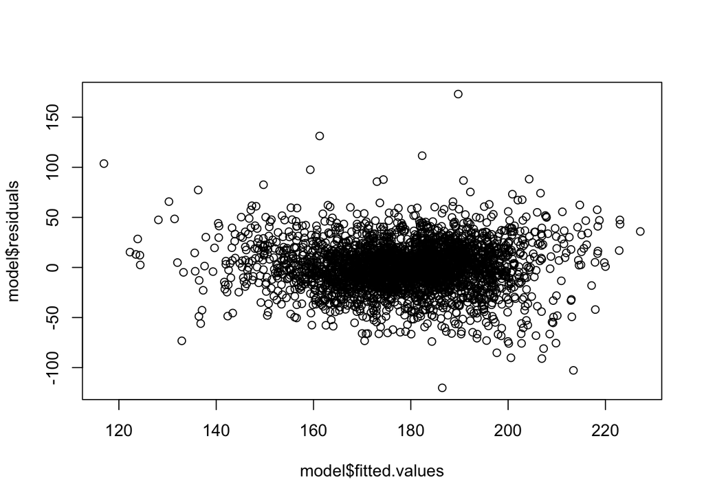

```r
plot(model$fitted.values, model$residuals)
```

The residuals are clustered at the center, but increase in spread at the extremes. This may indicate slight heteroscedasticity, which is a violation of the constant variance assumption.

### Fitted Values vs Residuals Plot

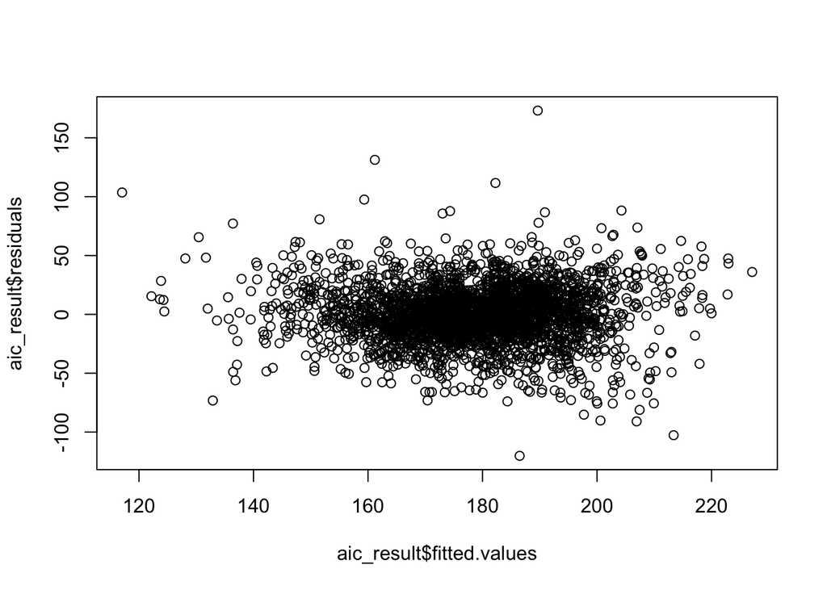

```r
plot(aic_result$fitted.values, aic_result$residuals)
```

The residuals are clustered at the center, but increase in spread at the extremes. This may indicate slight heteroscedasticity, which is a violation of the constant variance assumption.

### Q-Q Plot

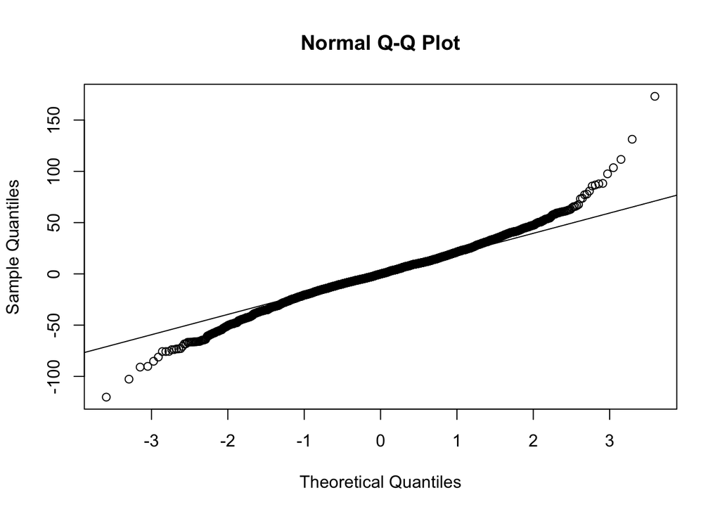

```r
qqnorm(aic_result$residuals)
qqline(aic_result$residuals)
```

There are quite a number of points that deviate from the line. There is evidence for non normal residuals

### Lagged Residuals Plot

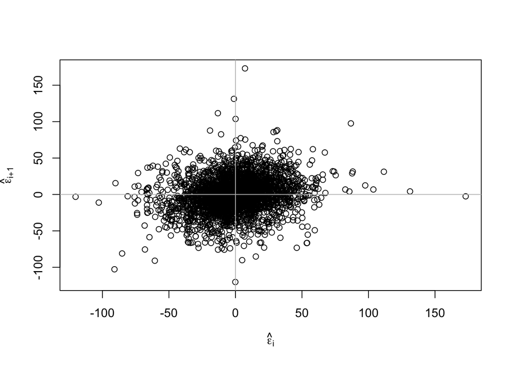

```r
n <- length(residuals(model))
plot(tail(residuals(model),n-1) ~ head(residuals(model),n-1), xlab=expression(hat(epsilon)[i]),ylab=expression(hat(epsilon)[i+1]))
abline(h=0,v=0,col=grey(0.75))
```

The lagged residual plot does not show a linear relationship between consecutive residuals. One residual does not strongly predict the next.

# Step Five

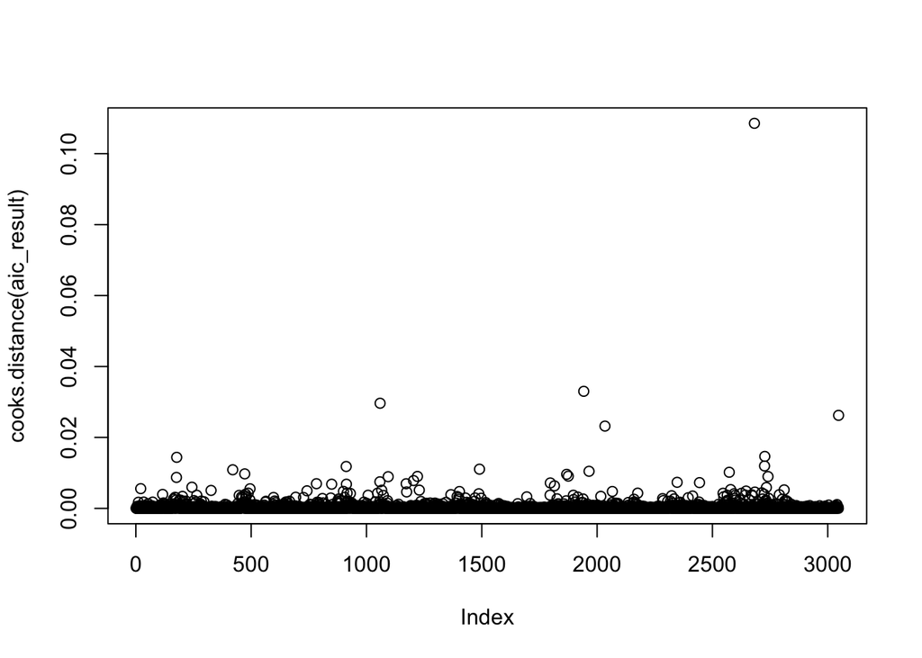

```r
plot(cooks.distance(aic_result))
```

From observing the cooks distance plot, we can see one clear outlier. Most are very close to 0, very low cooks distance numbers.

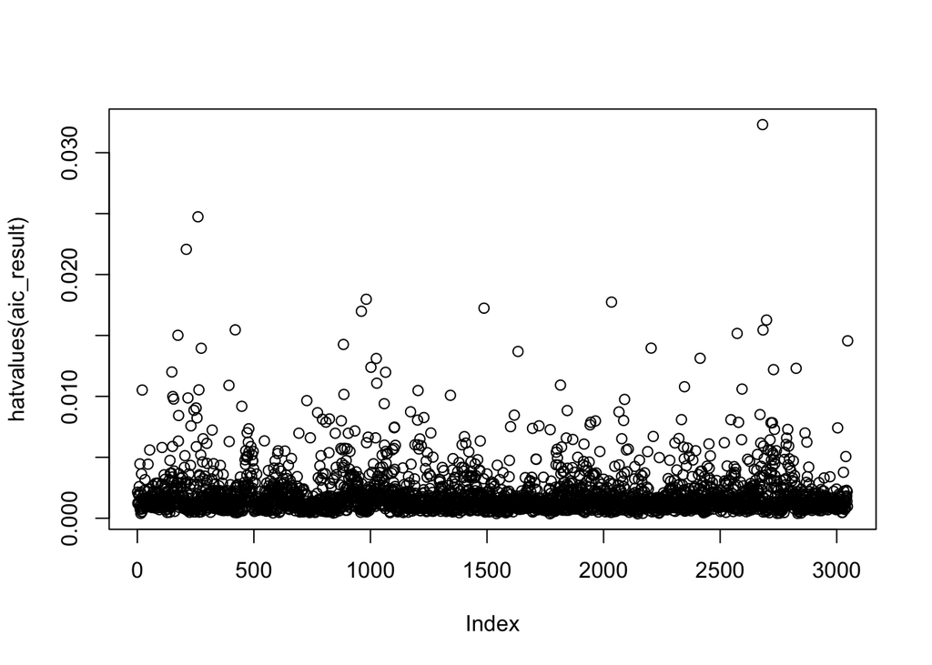

```r
plot(hatvalues(aic_result))
```

Observing the hatvalues also suggest one outlier, but the points are more variably spread. There are less points concentrated on the x axis.

# Step Six

From the information gathered in Step Four, we conclude that a transformation is needed. To correct this, I will use a Box-Cox transformation

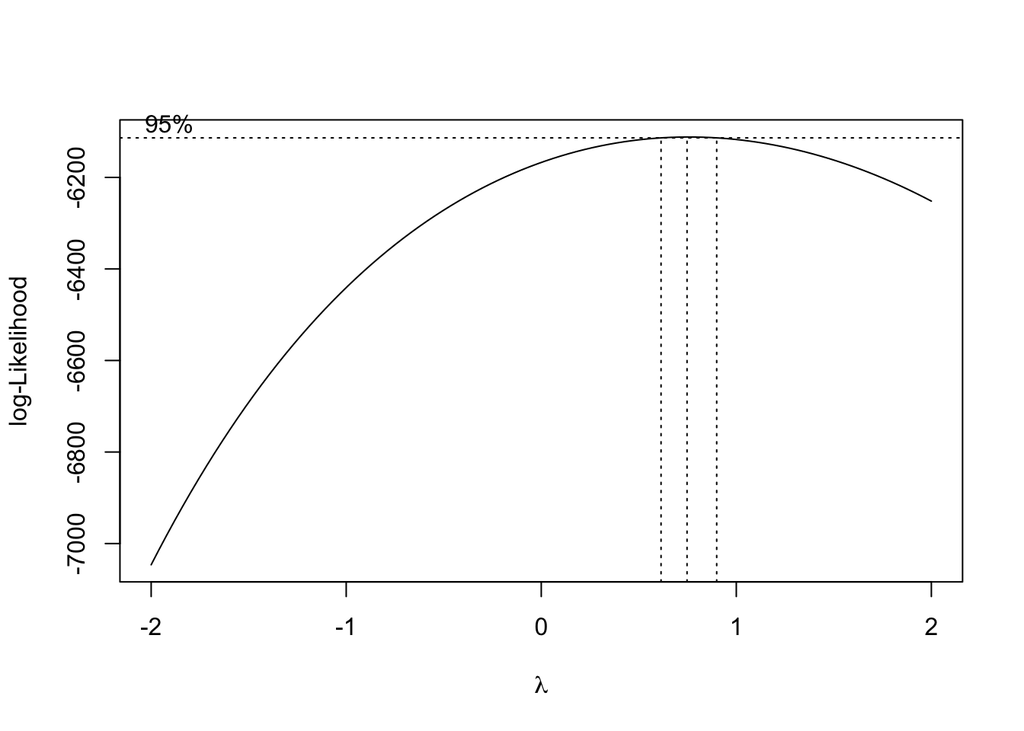

```r
bc <- boxcox(model, plotit=T)
```

```r
lambda <- bc$x[which.max(bc$y)]
lambda
```

```
[1] 0.7474747
```

```r
formula2 <- as.formula(TARGET_deathRate^lambda ~ povertyPercent + PctPublicCoverage + PctEmpPrivCoverage + PctPrivateCoverage + studyPerCap + medIncome + MedianAge)
modelBox <- lm(formula2, data=cancer_df)
summary(modelBox)
```

```
Call:
lm(formula = formula2, data = cancer_df)

Residuals:
     Min       1Q   Median       3Q      Max
-26.6464  -2.6620   0.0447   2.7795  31.5744

Coefficients:
                     Estimate Std. Error t value Pr(>|t|)
(Intercept)         4.101e+01  2.014e+00  20.366  < 2e-16 ***
povertyPercent      1.200e-01  2.830e-02   4.241 2.29e-05 ***
PctPublicCoverage   2.147e-01  1.966e-02  10.920  < 2e-16 ***
PctEmpPrivCoverage  2.773e-01  1.943e-02  14.277  < 2e-16 ***
PctPrivateCoverage -1.315e-01  1.903e-02  -6.909 5.90e-12 ***
studyPerCap        -1.037e-04  1.660e-04  -0.625    0.532
medIncome          -1.209e-04  1.431e-05  -8.446  < 2e-16 ***
MedianAge           1.030e-03  1.937e-03   0.532    0.595
---
Signif. codes:  0 '***' 0.001 '**' 0.01 '*' 0.05 '.' 0.1 ' ' 1

Residual standard error: 4.816 on 3039 degrees of freedom
Multiple R-squared:  0.263, Adjusted R-squared:  0.2613
F-statistic: 154.9 on 7 and 3039 DF,  p-value: < 2.2e-16
```

# Step Seven

```r
summary_model <- summary(modelBox)
coef <- summary_model$coefficients
coef_df <- as.data.frame(coef)
coef_df <- coef_df[, c("Estimate", "Pr(>|t|)")]
colnames(coef_df) <- c("Parameter Estimate", "p-value")
print(coef_df)
```

```
                   Parameter Estimate      p-value
(Intercept)             41.0079352787 1.565360e-86
povertyPercent           0.1200135862 2.294789e-05
PctPublicCoverage        0.2146638982 2.952828e-27
PctEmpPrivCoverage       0.2773399677 8.332165e-45
PctPrivateCoverage      -0.1314676344 5.901611e-12
studyPerCap             -0.0001036752 5.322672e-01
medIncome               -0.0001208764 4.608306e-17
MedianAge                0.0010304328 5.947387e-01
```

R-squared:

```r
summary_model$r.squared
```

```
[1] 0.2629508
```

```r
confint(modelBox, "PctEmpPrivCoverage", level=0.95)
```

```
                       2.5 %    97.5 %
PctEmpPrivCoverage 0.2392503 0.3154296
```

```r
cancer_median <- data.frame(
  povertyPercent = median(cancer_df$povertyPercent, na.rm = TRUE),
  PctPublicCoverage = median(cancer_df$PctPublicCoverage, na.rm = TRUE),
  PctEmpPrivCoverage = median(cancer_df$PctEmpPrivCoverage, na.rm = TRUE),
  PctPrivateCoverage = median(cancer_df$PctPrivateCoverage, na.rm = TRUE),
  studyPerCap = median(cancer_df$studyPerCap, na.rm = TRUE),
  medIncome = median(cancer_df$medIncome, na.rm = TRUE),
  MedianAge = median(cancer_df$MedianAge, na.rm = TRUE)
)

pred <- predict(modelBox, newdata = cancer_median, interval = "confidence", level = 0.95)
print(pred)
```

```
       fit      lwr      upr
1 48.12637 47.92785 48.32489
```

```r
predict(modelBox, newdata = cancer_median, interval = "prediction", level = 0.95)
```

```
       fit      lwr      upr
1 48.12637 38.68152 57.57122
```